# Project: Investigate a Dataset - [TMDb movie data]

- Introduction
- Data Wrangling
- Exploratory Data Analysis
- Conclusions

## Introduction

### Dataset Description

**The Columns**

| id | name | description |
| --- | --- | --- |
| 0 | id | Unique identifier for the movie |
| 1 | imdb_id | IMDB unique identifier for the movie |
| 2 | popularity | Popularity score of the movie |
| 3 | budget | Budget of the movie |
| 4 | revenue | Revenue generated by the movie |
| 5 | original_title | Original title of the movie |
| 6 | cast | Main cast of the movie |
| 7 | homepage | Official homepage URL of the movie |
| 8 | director | Director of the movie |
| 9 | tagline | Tagline of the movie |
| 10 | keywords | Keywords associated with the movie |
| 11 | overview | Brief overview or summary of the movie |
| 12 | runtime | Runtime of the movie in minutes |
| 13 | genres | Genres the movie belongs to |
| 14 | production_companies | Companies involved in the production of the movie |
| 15 | release_date | Release date of the movie |
| 16 | vote_count | Number of votes the movie received |
| 17 | vote_average | Average vote score of the movie |
| 18 | release_year | Release year of the movie |
| 19 | budget_adj | Inflation-adjusted budget of the movie |
| 20 | revenue_adj | Inflation-adjusted revenue of the movie |

### Question(s) for Analysis

```
Q1. What is the total Number of Movies Produced by Year and Genre?
Q2. What is the total Revenue on Movies by Year?
Q3. What Genres generated the most Revenue?
Q4. Does higher popularity value mean high revenue for movies?
Q5. What are the most common keywords associated with high-revenue movies?
Q6. Which directors have the highest average movie revenue?
Q7. Is there a correlation between the revenue and the budget of movies?
Q8. Which production companies produce the highest-grossing movies?
Q9. Correlation Between Vote Count/Vote Average and Revenue
```

```python
#Importing Necessary Libraries
import pandas as pd
import numpy as np
import matplotlib.pyplot as plt
import seaborn as sns
from IPython.display import display
%matplotlib inline
```

## Data Wrangling

### Loading the Data

```python
# here we Load the dataset
file_path = 'tmdb-movies.csv'
data = pd.read_csv(file_path)
```

### Exploring the Data

```python
# now we display some rows from the beginning and the end of the dataset
data.head()
```

|  | id | imdb_id | popularity | budget | revenue | original_title | cast | homepage | director | tagline | ... | overview | runtime | genres | production_companies | release_date | vote_count | vote_average | release_year | budget_adj | revenue_adj |
| --- | --- | --- | --- | --- | --- | --- | --- | --- | --- | --- | --- | --- | --- | --- | --- | --- | --- | --- | --- | --- | --- |
| 0 | 135397 | tt0369610 | 32.985763 | 150000000 | 1513528810 | Jurassic World | Chris Pratt\|Bryce Dallas Howard\|Irrfan Khan\|Vi... | http://www.jurassicworld.com/ | Colin Trevorrow | The park is open. | ... | Twenty-two years after the events of Jurassic ... | 124 | Action\|Adventure\|Science Fiction\|Thriller | Universal Studios\|Amblin Entertainment\|Legenda... | 6/9/15 | 5562 | 6.5 | 2015 | 1.379999e+08 | 1.392446e+09 |
| 1 | 76341 | tt1392190 | 28.419936 | 150000000 | 378436354 | Mad Max: Fury Road | Tom Hardy\|Charlize Theron\|Hugh Keays-Byrne\|Nic... | http://www.madmaxmovie.com/ | George Miller | What a Lovely Day. | ... | An apocalyptic story set in the furthest reach... | 120 | Action\|Adventure\|Science Fiction\|Thriller | Village Roadshow Pictures\|Kennedy Miller Produ... | 5/13/15 | 6185 | 7.1 | 2015 | 1.379999e+08 | 3.481613e+08 |
| 2 | 262500 | tt2908446 | 13.112507 | 110000000 | 295238201 | Insurgent | Shailene Woodley\|Theo James\|Kate Winslet\|Ansel... | http://www.thedivergentseries.movie/#insurgent | Robert Schwentke | One Choice Can Destroy You | ... | Beatrice Prior must confront her inner demons ... | 119 | Adventure\|Science Fiction\|Thriller | Summit Entertainment\|Mandeville Films\|Red Wago... | 3/18/15 | 2480 | 6.3 | 2015 | 1.012000e+08 | 2.716190e+08 |
| 3 | 140607 | tt2488496 | 11.173104 | 200000000 | 2068178225 | Star Wars: The Force Awakens | Harrison Ford\|Mark Hamill\|Carrie Fisher\|Adam D... | http://www.starwars.com/films/star-wars-episod... | J.J. Abrams | Every generation has a story. | ... | Thirty years after defeating the Galactic Empi... | 136 | Action\|Adventure\|Science Fiction\|Fantasy | Lucasfilm\|Truenorth Productions\|Bad Robot | 12/15/15 | 5292 | 7.5 | 2015 | 1.839999e+08 | 1.902723e+09 |
| 4 | 168259 | tt2820852 | 9.335014 | 190000000 | 1506249360 | Furious 7 | Vin Diesel\|Paul Walker\|Jason Statham\|Michelle ... | http://www.furious7.com/ | James Wan | Vengeance Hits Home | ... | Deckard Shaw seeks revenge against Dominic Tor... | 137 | Action\|Crime\|Thriller | Universal Pictures\|Original Film\|Media Rights ... | 4/1/15 | 2947 | 7.3 | 2015 | 1.747999e+08 | 1.385749e+09 |

5 rows × 21 columns

```python
data.tail()  # last 5 (ending) of the set
```

|  | id | imdb_id | popularity | budget | revenue | original_title | cast | homepage | director | tagline | ... | overview | runtime | genres | production_companies | release_date | vote_count | vote_average | release_year | budget_adj | revenue_adj |
| --- | --- | --- | --- | --- | --- | --- | --- | --- | --- | --- | --- | --- | --- | --- | --- | --- | --- | --- | --- | --- | --- |
| 10861 | 21 | tt0060371 | 0.080598 | 0 | 0 | The Endless Summer | Michael Hynson\|Robert August\|Lord 'Tally Ho' B... | NaN | Bruce Brown | NaN | ... | The Endless Summer, by Bruce Brown, is one of ... | 95 | Documentary | Bruce Brown Films | 6/15/66 | 11 | 7.4 | 1966 | 0.000000 | 0.0 |
| 10862 | 20379 | tt0060472 | 0.065543 | 0 | 0 | Grand Prix | James Garner\|Eva Marie Saint\|Yves Montand\|Tosh... | NaN | John Frankenheimer | Cinerama sweeps YOU into a drama of speed and ... | ... | Grand Prix driver Pete Aron is fired by his te... | 176 | Action\|Adventure\|Drama | Cherokee Productions\|Joel Productions\|Douglas ... | 12/21/66 | 20 | 5.7 | 1966 | 0.000000 | 0.0 |
| 10863 | 39768 | tt0060161 | 0.065141 | 0 | 0 | Beregis Avtomobilya | Innokentiy Smoktunovskiy\|Oleg Efremov\|Georgi Z... | NaN | Eldar Ryazanov | NaN | ... | An insurance agent who moonlights as a carthie... | 94 | Mystery\|Comedy | Mosfilm | 1/1/66 | 11 | 6.5 | 1966 | 0.000000 | 0.0 |
| 10864 | 21449 | tt0061177 | 0.064317 | 0 | 0 | What's Up, Tiger Lily? | Tatsuya Mihashi\|Akiko Wakabayashi\|Mie Hama\|Joh... | NaN | Woody Allen | WOODY ALLEN STRIKES BACK! | ... | In comic Woody Allen's film debut, he took the... | 80 | Action\|Comedy | Benedict Pictures Corp. | 11/2/66 | 22 | 5.4 | 1966 | 0.000000 | 0.0 |
| 10865 | 22293 | tt0060666 | 0.035919 | 19000 | 0 | Manos: The Hands of Fate | Harold P. Warren\|Tom Neyman\|John Reynolds\|Dian... | NaN | Harold P. Warren | It's Shocking! It's Beyond Your Imagination! | ... | A family gets lost on the road and stumbles up... | 74 | Horror | Norm-Iris | 11/15/66 | 15 | 1.5 | 1966 | 127642.279154 | 0.0 |

5 rows × 21 columns

```python
# here we print number of rows and number of columns using .shape
print(f"The dataset conatins {data.shape[0]:,} records, and {data.shape[1]:,} features")
```

```
The dataset conatins 10,866 records, and 21 features
```

```python
# below are some statistics of the dataset (mean, median, min, mix, etc...)
data.describe()
```

|  | id | popularity | budget | revenue | runtime | vote_count | vote_average | release_year | budget_adj | revenue_adj |
| --- | --- | --- | --- | --- | --- | --- | --- | --- | --- | --- |
| count | 10866.000000 | 10866.000000 | 1.086600e+04 | 1.086600e+04 | 10866.000000 | 10866.000000 | 10866.000000 | 10866.000000 | 1.086600e+04 | 1.086600e+04 |
| mean | 66064.177434 | 0.646441 | 1.462570e+07 | 3.982332e+07 | 102.070863 | 217.389748 | 5.974922 | 2001.322658 | 1.755104e+07 | 5.136436e+07 |
| std | 92130.136561 | 1.000185 | 3.091321e+07 | 1.170035e+08 | 31.381405 | 575.619058 | 0.935142 | 12.812941 | 3.430616e+07 | 1.446325e+08 |
| min | 5.000000 | 0.000065 | 0.000000e+00 | 0.000000e+00 | 0.000000 | 10.000000 | 1.500000 | 1960.000000 | 0.000000e+00 | 0.000000e+00 |
| 25% | 10596.250000 | 0.207583 | 0.000000e+00 | 0.000000e+00 | 90.000000 | 17.000000 | 5.400000 | 1995.000000 | 0.000000e+00 | 0.000000e+00 |
| 50% | 20669.000000 | 0.383856 | 0.000000e+00 | 0.000000e+00 | 99.000000 | 38.000000 | 6.000000 | 2006.000000 | 0.000000e+00 | 0.000000e+00 |
| 75% | 75610.000000 | 0.713817 | 1.500000e+07 | 2.400000e+07 | 111.000000 | 145.750000 | 6.600000 | 2011.000000 | 2.085325e+07 | 3.369710e+07 |
| max | 417859.000000 | 32.985763 | 4.250000e+08 | 2.781506e+09 | 900.000000 | 9767.000000 | 9.200000 | 2015.000000 | 4.250000e+08 | 2.827124e+09 |

From the above table, we conclude some information as follows:

- There is significant variability in budgets, revenues, and popularity scores, indicating a diverse dataset ranging from low-budget to high-budget and low-grossing to high-grossing movies.
- Many movies have zero budgets and revenues recorded, which maybe means missing or incomplete data for these fields.
- The dataset includes movies released from 1960 to 2015, providing a wide historical range.
- Adjusted budget and revenue follow similar trends to their non-adjusted counterparts, indicating the influence of inflation adjustments.

```python
# exploring the number of unique values in each attribute
data.nunique()
```

```
id                      10865
imdb_id                 10855
popularity              10814
budget                    557
revenue                  4702
original_title          10571
cast                    10719
homepage                 2896
director                 5067
tagline                  7997
keywords                 8804
overview                10847
runtime                   247
genres                   2039
production_companies     7445
release_date             5909
vote_count               1289
vote_average               72
release_year               56
budget_adj               2614
revenue_adj              4840
dtype: int64
```

- Looking at the values obtained above, columns that have high unique values can be considered as high-cardinality categorical features
- columns that have low unique values can be considered as categorical features

```python
# here we obtain the number of null/missing values in each of the columns
data.isnull().sum()
```

```
id                         0
imdb_id                   10
popularity                 0
budget                     0
revenue                    0
original_title             0
cast                      76
homepage                7930
director                  44
tagline                 2824
keywords                1493
overview                   4
runtime                    0
genres                    23
production_companies    1030
release_date               0
vote_count                 0
vote_average               0
release_year               0
budget_adj                 0
revenue_adj                0
dtype: int64
```

```python
# here we show datatypes of the columns and if there any missing/null values in each column.
data.info()
```

```
<class 'pandas.core.frame.DataFrame'>
RangeIndex: 10866 entries, 0 to 10865
Data columns (total 21 columns):
 #   Column                Non-Null Count  Dtype
---  ------                --------------  -----
 0   id                    10866 non-null  int64
 1   imdb_id               10856 non-null  object
 2   popularity            10866 non-null  float64
 3   budget                10866 non-null  int64
 4   revenue               10866 non-null  int64
 5   original_title        10866 non-null  object
 6   cast                  10790 non-null  object
 7   homepage              2936 non-null   object
 8   director              10822 non-null  object
 9   tagline               8042 non-null   object
 10  keywords              9373 non-null   object
 11  overview              10862 non-null  object
 12  runtime               10866 non-null  int64
 13  genres                10843 non-null  object
 14  production_companies  9836 non-null   object
 15  release_date          10866 non-null  object
 16  vote_count            10866 non-null  int64
 17  vote_average          10866 non-null  float64
 18  release_year          10866 non-null  int64
 19  budget_adj            10866 non-null  float64
 20  revenue_adj           10866 non-null  float64
dtypes: float64(4), int64(6), object(11)
memory usage: 1.7+ MB
```

- Looking at the above output, we can see that some of the columns have missing values (imdb_id, cast, director, genres, overview, production_companies, keywords, tagline, homepage), also we can see the data types of each column, which are in general correct, but preferably for the object values, we change them to string, also the release date which should be used with the data type 'date', but since i won't need it in my analysis (drop it), there is no need to convert it.

### Data Cleaning

- Dropping Unimportant Columns, duplicates, and null values

I will drop some columns below, as they are insignigicant for my analysis

```python
# dropping insignificant coluumns
data.drop(['imdb_id', 'id', 'cast', 'homepage', 'tagline',  'overview', 'release_date'], axis = 1, inplace=True)
# To take a look at how the data has become after the dropping
data.head()
```

|  | popularity | budget | revenue | original_title | director | keywords | runtime | genres | production_companies | vote_count | vote_average | release_year | budget_adj | revenue_adj |
| --- | --- | --- | --- | --- | --- | --- | --- | --- | --- | --- | --- | --- | --- | --- |
| 0 | 32.985763 | 150000000 | 1513528810 | Jurassic World | Colin Trevorrow | monster\|dna\|tyrannosaurus rex\|velociraptor\|island | 124 | Action\|Adventure\|Science Fiction\|Thriller | Universal Studios\|Amblin Entertainment\|Legenda... | 5562 | 6.5 | 2015 | 1.379999e+08 | 1.392446e+09 |
| 1 | 28.419936 | 150000000 | 378436354 | Mad Max: Fury Road | George Miller | future\|chase\|post-apocalyptic\|dystopia\|australia | 120 | Action\|Adventure\|Science Fiction\|Thriller | Village Roadshow Pictures\|Kennedy Miller Produ... | 6185 | 7.1 | 2015 | 1.379999e+08 | 3.481613e+08 |
| 2 | 13.112507 | 110000000 | 295238201 | Insurgent | Robert Schwentke | based on novel\|revolution\|dystopia\|sequel\|dyst... | 119 | Adventure\|Science Fiction\|Thriller | Summit Entertainment\|Mandeville Films\|Red Wago... | 2480 | 6.3 | 2015 | 1.012000e+08 | 2.716190e+08 |
| 3 | 11.173104 | 200000000 | 2068178225 | Star Wars: The Force Awakens | J.J. Abrams | android\|spaceship\|jedi\|space opera\|3d | 136 | Action\|Adventure\|Science Fiction\|Fantasy | Lucasfilm\|Truenorth Productions\|Bad Robot | 5292 | 7.5 | 2015 | 1.839999e+08 | 1.902723e+09 |
| 4 | 9.335014 | 190000000 | 1506249360 | Furious 7 | James Wan | car race\|speed\|revenge\|suspense\|car | 137 | Action\|Crime\|Thriller | Universal Pictures\|Original Film\|Media Rights ... | 2947 | 7.3 | 2015 | 1.747999e+08 | 1.385749e+09 |

```python
# checking the number of duplicate entries if there exists any
sum(data.duplicated())
```

```
1
```

```python
# dropping the duplicated entry.
data.drop_duplicates(inplace=True)
# checking again
sum(data.duplicated())
```

```
0
```

```python
# let's take a look at the missing values for each column
data.info()
```

```
<class 'pandas.core.frame.DataFrame'>
Int64Index: 10865 entries, 0 to 10865
Data columns (total 14 columns):
 #   Column                Non-Null Count  Dtype
---  ------                --------------  -----
 0   popularity            10865 non-null  float64
 1   budget                10865 non-null  int64
 2   revenue               10865 non-null  int64
 3   original_title        10865 non-null  object
 4   director              10821 non-null  object
 5   keywords              9372 non-null   object
 6   runtime               10865 non-null  int64
 7   genres                10842 non-null  object
 8   production_companies  9835 non-null   object
 9   vote_count            10865 non-null  int64
 10  vote_average          10865 non-null  float64
 11  release_year          10865 non-null  int64
 12  budget_adj            10865 non-null  float64
 13  revenue_adj           10865 non-null  float64
dtypes: float64(4), int64(5), object(5)
memory usage: 1.2+ MB
```

Now if we look at the column entries above, we see that director, keywords, genres, production_companies are missing value noting that genres and director have small amount of missing values, on the other hand, production_companies and keywords have a lot of missing values, so i took the following approach:

- in genres and director, i will drop the missing values on thoose, drop both production_companies and keywords,and then make this dataset which is called data as my main dataset, which will be used in most of my research questions
- in production_companies and keywords, i will have a seperate data set for each questions, for example, the question with the keywords being the critical column, i will use a data set that has production_companies dropped, and vice versa for the production_companies question

**the benefit of doing so makes the missing values on the keywords and production_companies not affect other columns (because of their large number of missing values, which those rows then need to be dropped), making the most accurate results**

```python
# Drop rows with missing values in critical columns
data = data.dropna(subset=['genres','director'])
```

```python
data.isnull().sum()
```

```
popularity                 0
budget                     0
revenue                    0
original_title             0
director                   0
keywords                1449
runtime                    0
genres                     0
production_companies     994
vote_count                 0
vote_average               0
release_year               0
budget_adj                 0
revenue_adj                0
dtype: int64
```

```python
# Convert object type columns to string type
cols_to_convert = ['production_companies', 'genres', 'keywords', 'director', 'original_title']
data[cols_to_convert] = data[cols_to_convert].astype(str)
```

```python
# as i was exploring the data, some 'nan' strings were visible in the outputs, so this had to be done
data = data[data != 'nan']
```

converting object columns to str ensures that all entries, including numeric and NaN values, are treated as strings within those columns.

```python
# Saving the data before removing the 'production_companies' and 'keywords' columns

# These columns will be used only in 2 research questions

# Create a copy of the data
rawdata1 = data.copy()

# Drop the 'production_companies' column
rawdata1.drop('production_companies', axis=1, inplace=True)

# Drop rows with missing values in the 'keywords' column
rawdata1.dropna(subset=['keywords'], inplace=True)

# Now rawdata1 is ready for questions related to keywords
```

```python
# Same process as above goes here, but for production_companies columns
rawdata2 = data.copy()

rawdata2.drop('keywords', axis=1, inplace=True)

rawdata2.dropna(subset=['production_companies'], inplace=True)
```

```python
# Verify the changes
print(rawdata1.isnull().sum())
print(rawdata2.isnull().sum())
```

```
popularity        0
budget            0
revenue           0
original_title    0
director          0
keywords          0
runtime           0
genres            0
vote_count        0
vote_average      0
release_year      0
budget_adj        0
revenue_adj       0
dtype: int64
popularity              0
budget                  0
revenue                 0
original_title          0
director                0
runtime                 0
genres                  0
production_companies    0
vote_count              0
vote_average            0
release_year            0
budget_adj              0
revenue_adj             0
dtype: int64
```

```python
# Now we can drop them from our main dataset
data.drop(['production_companies','keywords'], axis = 1, inplace=True)
```

```python
# verify the missing values of columns in the main data set
data.isnull().sum()
```

```
popularity        0
budget            0
revenue           0
original_title    0
director          0
runtime           0
genres            0
vote_count        0
vote_average      0
release_year      0
budget_adj        0
revenue_adj       0
dtype: int64
```

```python
print(data.shape)
print(rawdata1.shape)
print(rawdata2.shape)
```

```
(10800, 12)
(9351, 13)
(9806, 13)
```

# Exploratory Data Analysis

- Quick Visualization of Features Distribution
- Quick Visualization of Features Relationship
- Relationship Between Independent Features
- Distribution of Dependent Features/Variables
- Total Number of Movies Produced by Year
- Total Number of Movies Produced by Genre
- Total Number of Movies Produced byYear and Genre
- Total Revenue on Movies by Year

### Visualization of numerical columns Histograms

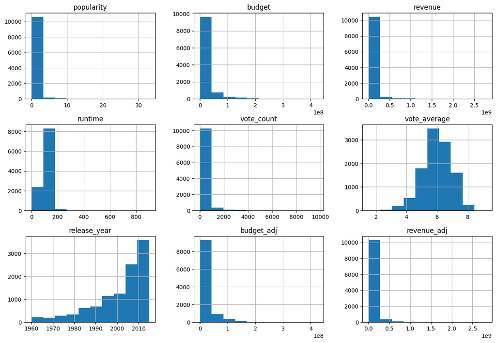

```python
# Distribution of the numerical features in the dataset.
data.hist(figsize=(15,10));
```

Some insights taken from the above graphs:

- There is a typical pattern where most movies achieve moderate levels of popularity and engagement, with a few standout hits that are far more popular and widely voted on.
- Most movies work with moderate budgets and revenues, indicating a concentration of financial risk and return in a smaller subset of the film industry. This suggests a high risk, high reward scenario particularly applicable to blockbusters.
- The increase in movies released over the decades highlights industry growth, potentially driven by advancements in technology and expanding global markets.
- The distribution of vote averages shows that most movies are considered of average quality by viewers, with fewer films rated as poor or excellent.

### Visualization of numerical columns Relationship

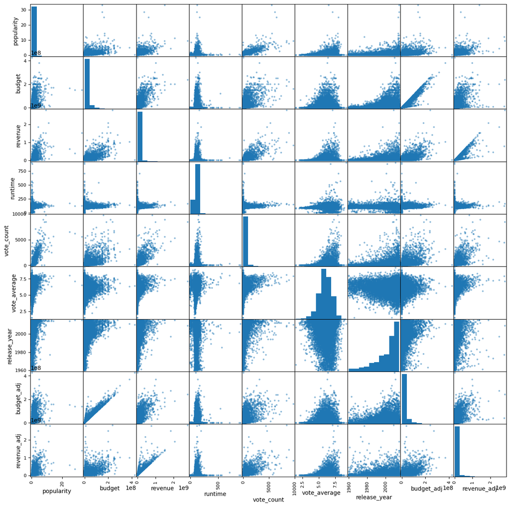

```python
# scatter plots for Visualization
pd.plotting.scatter_matrix(data, figsize=(15,15));
```

#### some of the relationships between dependent and independent variables

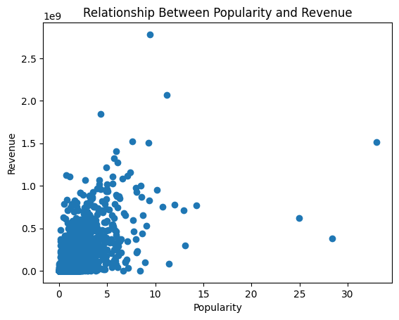

```python
# Scatter plot that focuses on the Relationship Between Popularity and Revenue
plt.scatter(data['popularity'], data['revenue'])
plt.title('Relationship Between Popularity and Revenue')
plt.xlabel('Popularity')
plt.ylabel('Revenue')
plt.show()
```

- There is a moderate positive correlation between popularity and revenue. While more popular movies tend to earn higher revenues, the relationship is not strictly proportional
- The variability in revenue at lower levels of popularity suggests that other factors significantly influence a movie's financial success

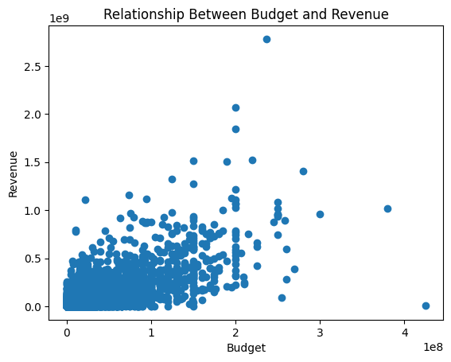

```python
# Scatter plot that focuses on the Relationship Budget and Revenue
plt.scatter(data['budget'], data['revenue'])
plt.title('Relationship Between Budget and Revenue')
plt.xlabel('Budget')
plt.ylabel('Revenue')
plt.show()
```

- There is a clear positive correlation between budget and revenue, which supports the notion that investing more into the production and promotion of a movie can lead to higher financial returns. However, the relationship is not perfectly linear, indicating the influence of other factors

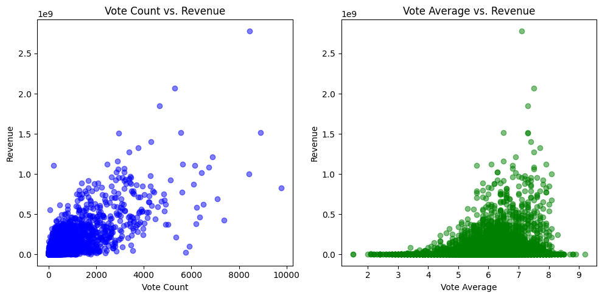

```python
# Scatter plot that focuses on the Relationship vote_count/vote_average and Revenue
plt.figure(figsize=(10, 5))

# Plotting both vote count and vote average in the same figure for comparison
plt.subplot(1, 2, 1)
plt.scatter(data['vote_count'], data['revenue'], alpha=0.5, color='blue')
plt.title('Vote Count vs. Revenue')
plt.xlabel('Vote Count')
plt.ylabel('Revenue')

plt.subplot(1, 2, 2)
plt.scatter(data['vote_average'], data['revenue'], alpha=0.5, color='green')
plt.title('Vote Average vs. Revenue')
plt.xlabel('Vote Average')
plt.ylabel('Revenue')

plt.tight_layout()
plt.show()
```

- The first plot indicates that the number of votes (i.e., the level of viewer engagement or interest) correlates positively with revenue. This could suggest that movies that are more engaging or marketed more effectively tend to draw both more viewers and higher box office earnings. This metric could be indicative of a movie’s popularity and, indirectly, its promotional reach
- The second plot suggests that while there is a positive correlation between vote averages and revenue, the relationship is not as strong or direct. This implies that simply having a high average rating does not guarantee high revenue; the content must also appeal broadly enough to attract a large audience

## Research Questions

### What is the total number of movies produced by genre x year?

```python
data['genres'] = data['genres'].str.split('|')

# Ehere we use the explode method for the genres column
data_exploded = data.explode('genres')

# The explode function in Pandas is used to transform each element of a list-like to a row,
# replicating the index values. This method is particularly useful when dealing
# with columns that contain lists or multiple values separated by a delimiter that have
# been converted into lists

#here's an example of how the data has become:
data_exploded.head()
```

|  | popularity | budget | revenue | original_title | director | runtime | genres | vote_count | vote_average | release_year | budget_adj | revenue_adj |
| --- | --- | --- | --- | --- | --- | --- | --- | --- | --- | --- | --- | --- |
| 0 | 32.985763 | 150000000 | 1513528810 | Jurassic World | Colin Trevorrow | 124 | Action | 5562 | 6.5 | 2015 | 1.379999e+08 | 1.392446e+09 |
| 0 | 32.985763 | 150000000 | 1513528810 | Jurassic World | Colin Trevorrow | 124 | Adventure | 5562 | 6.5 | 2015 | 1.379999e+08 | 1.392446e+09 |
| 0 | 32.985763 | 150000000 | 1513528810 | Jurassic World | Colin Trevorrow | 124 | Science Fiction | 5562 | 6.5 | 2015 | 1.379999e+08 | 1.392446e+09 |
| 0 | 32.985763 | 150000000 | 1513528810 | Jurassic World | Colin Trevorrow | 124 | Thriller | 5562 | 6.5 | 2015 | 1.379999e+08 | 1.392446e+09 |
| 1 | 28.419936 | 150000000 | 378436354 | Mad Max: Fury Road | George Miller | 120 | Action | 6185 | 7.1 | 2015 | 1.379999e+08 | 3.481613e+08 |

```python
#Value counts of movies for each genre by year.
genres_by_year = data_exploded.groupby('release_year')['genres'].value_counts()
```

```python
# here we find the unique release_year values.
unique_years = data.release_year.unique()

# here we sort the unique years in descending order using NumPy (for better visulization)
sorted_years_desc = np.sort(unique_years)[::-1]
print(sorted_years_desc)
```

```
[2015 2014 2013 2012 2011 2010 2009 2008 2007 2006 2005 2004 2003 2002
 2001 2000 1999 1998 1997 1996 1995 1994 1993 1992 1991 1990 1989 1988
 1987 1986 1985 1984 1983 1982 1981 1980 1979 1978 1977 1976 1975 1974
 1973 1972 1971 1970 1969 1968 1967 1966 1965 1964 1963 1962 1961 1960]
```

```python
#here we print the total count of movies by genres for each year.
years = np.array(data.release_year.unique())
for year in years:
    print(year, genres_by_year[year])
```

```
2015 genres
Drama              260
Thriller           171
Comedy             160
Horror             125
Action             107
Science Fiction     85
Adventure           69
Documentary         56
Romance             56
Crime               51
Family              44
Mystery             42
Animation           39
Fantasy             33
Music               33
TV Movie            20
History             15
War                  9
Western              6
Name: genres, dtype: int64
2014 genres
Drama              284
Comedy             184
Thriller           179
Action             129
Horror             105
Romance             83
Documentary         69
Adventure           67
Crime               65
Science Fiction     62
Family              43
Animation           36
Fantasy             36
Mystery             36
Music               27
War                 23
History             15
TV Movie            12
```

[output cut: 1104 more lines]

```
Thriller            8
Family              7
Western             7
Mystery             6
Romance             6
Science Fiction     6
Crime               5
War                 4
Animation           3
Horror              3
Fantasy             2
Foreign             2
History             2
Documentary         1
Name: genres, dtype: int64
```

- Now, we can plot this relationship 10 years at a time in order to see how it differs over the years

```
Total number of movies produced in this year: 1381
```

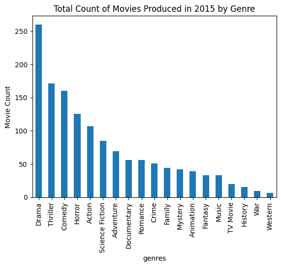

```python
#Plotting the total count of movies by genres in 2015
genres_by_year[2015].plot(kind = 'bar');
plt.ylabel('Movie Count')
plt.title('Total Count of Movies Produced in 2015 by Genre');
total_movies = genres_by_year[2015].sum()

print(f'Total number of movies produced in this year: {total_movies}')
```

```
Total number of movies produced in this year: 1193
```

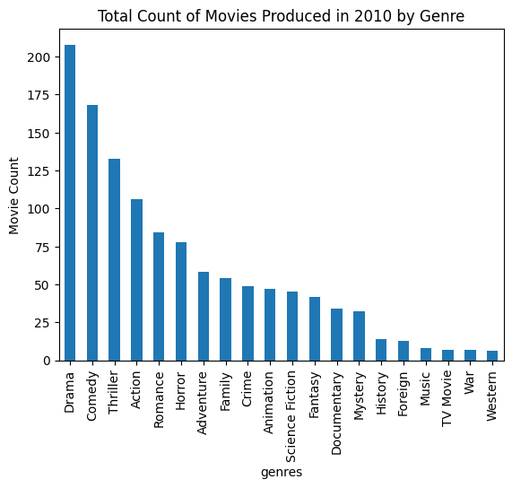

```python
#Plotting the total count of movies by genres in 2010
genres_by_year[2010].plot(kind = 'bar');
plt.ylabel('Movie Count')
plt.title('Total Count of Movies Produced in 2010 by Genre');
total_movies = genres_by_year[2010].sum()

print(f'Total number of movies produced in this year: {total_movies}')
```

```
Total number of movies produced in this year: 584
```

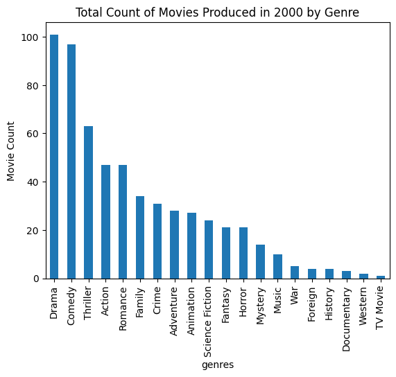

```python
#Plotting the total count of movies by genres in 2000
genres_by_year[2000].plot(kind = 'bar');
plt.ylabel('Movie Count')
plt.title('Total Count of Movies Produced in 2000 by Genre');
total_movies = genres_by_year[2000].sum()

print(f'Total number of movies produced in this year: {total_movies}')
```

```
Total number of movies produced in this year: 366
```

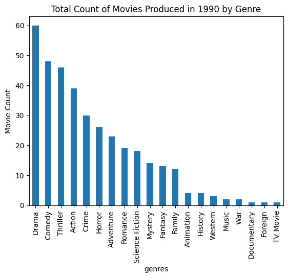

```python
#Plotting the total count of movies by genres in 1990
genres_by_year[1990].plot(kind = 'bar');
plt.ylabel('Movie Count')
plt.title('Total Count of Movies Produced in 1990 by Genre');
total_movies = genres_by_year[1990].sum()

print(f'Total number of movies produced in this year: {total_movies}')
```

```
Total number of movies produced in this year: 207
```

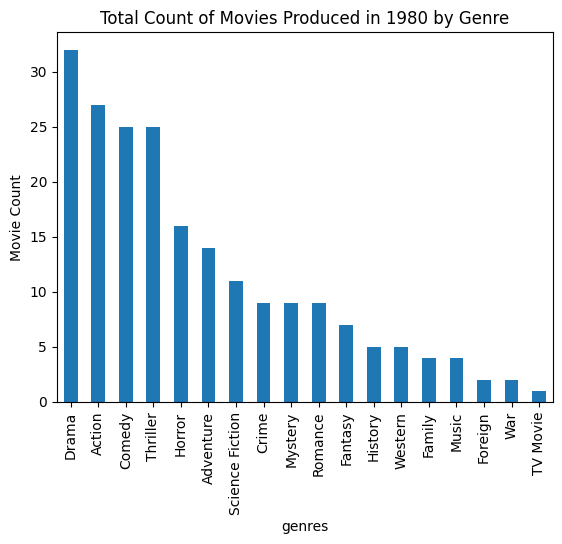

```python
#Plotting the total count of movies by genres in 1980
genres_by_year[1980].plot(kind = 'bar');
plt.ylabel('Movie Count')
plt.title('Total Count of Movies Produced in 1980 by Genre');
total_movies = genres_by_year[1980].sum()

print(f'Total number of movies produced in this year: {total_movies}')
```

```
Total number of movies produced in this year: 107
```

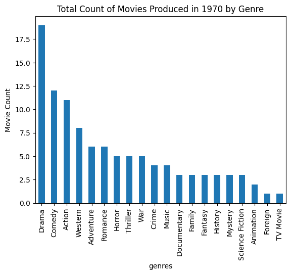

```python
#Plotting the total count of movies by genres in 1970
genres_by_year[1970].plot(kind = 'bar');
plt.ylabel('Movie Count')
plt.title('Total Count of Movies Produced in 1970 by Genre');
total_movies = genres_by_year[1970].sum()

print(f'Total number of movies produced in this year: {total_movies}')
```

```
Total number of movies produced in this year: 78
```

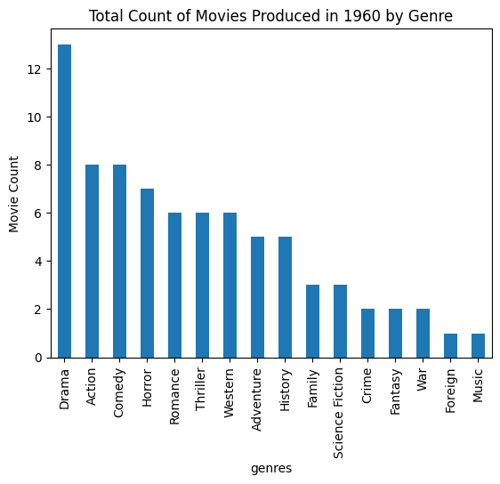

```python
#Plotting the total count of movies by genres in 1960
genres_by_year[1960].plot(kind = 'bar');
plt.ylabel('Movie Count')
plt.title('Total Count of Movies Produced in 1960 by Genre');
total_movies = genres_by_year[1960].sum()

print(f'Total number of movies produced in this year: {total_movies}')
```

## What is the total revenue on movies x year?

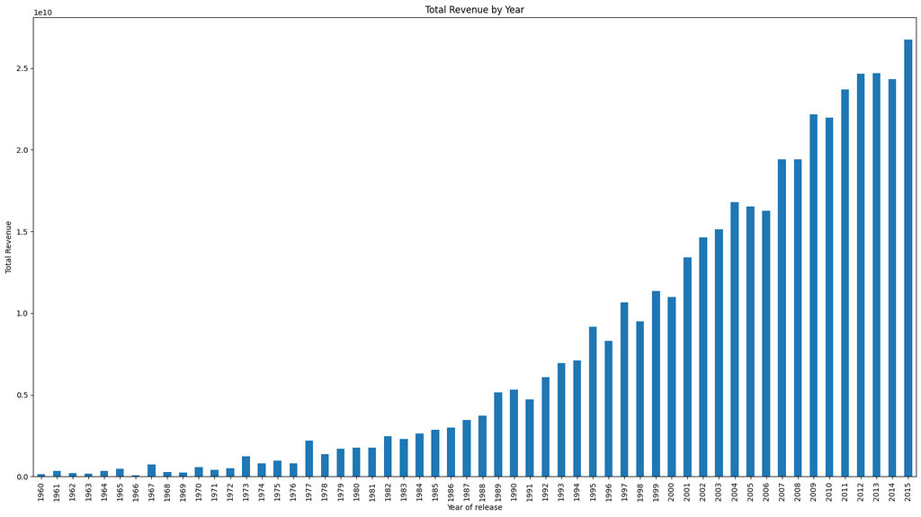

```python
#here we find the sum of revenue for each year.
data.groupby('release_year')['revenue'].sum().plot(kind = 'bar', figsize = (21, 11));
plt.ylabel('Total Revenue')
plt.xlabel('Year of release');
plt.title('Total Revenue by Year');
```

- The consistent increase in movie revenues over decades highlights the industry's ability to adapt and grow. Key factors likely include technological advancements in film production and distribution, globalization of the film market, and the strategic development of movie franchises and blockbuster hits.

## What genres had the most revenue?

```python
#Function to plot Genre aggregations.
def agg_genre(column):
    agg = data_exploded.groupby('genres')[column].mean()
    plt.title(f'average {column} x genre')
    plt.ylabel(f'average {column}');
    plt.xlabel('genres')
    return agg.plot(kind='bar', figsize=(10,8));
```

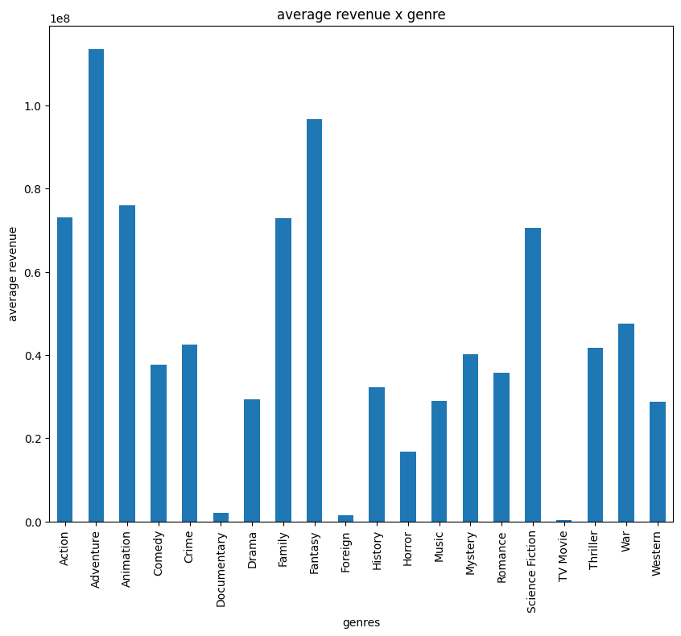

```python
#here we find the average revenue by genres, using our previously conducted function
agg_genre('revenue');
```

## Which of the genres has the most popularity?

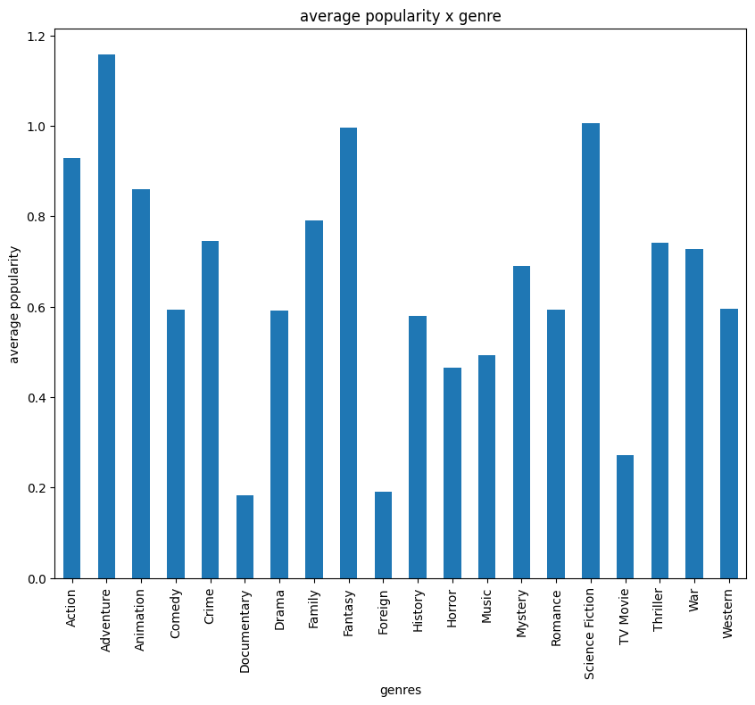

```python
# here is the average popularity by genres.
agg_genre('popularity');
```

### Do movies that have high popularity value also have high revenue?

```
The Pearson correlation coefficient between popularity and revenue is: 0.6630954377661433
```

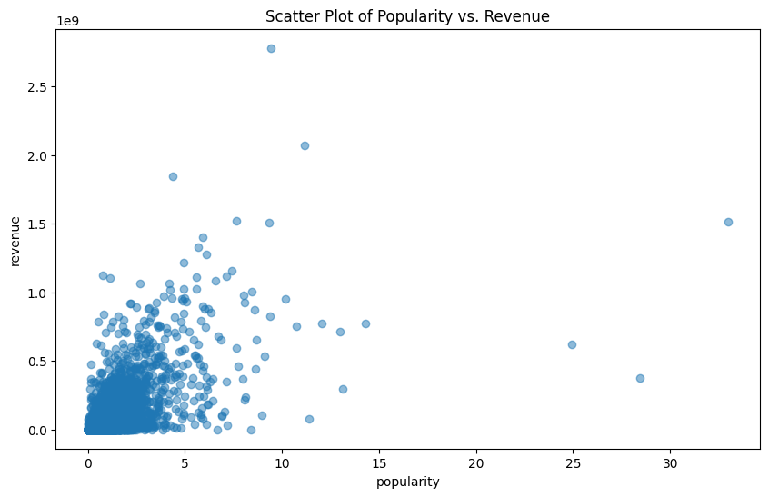

```python
# Calculate the Pearson correlation coefficient
correlation = data['popularity'].corr(data['revenue'])
print(f'The Pearson correlation coefficient between popularity and revenue is: {correlation}')

# Create a scatter plot
plt.figure(figsize=(10, 6))
plt.scatter(data['popularity'], data['revenue'], alpha=0.5)
plt.xlabel('popularity')
plt.ylabel('revenue')
plt.title('Scatter Plot of Popularity vs. Revenue')
plt.show()
```

```python
data.popularity.describe()
```

```
count    10800.000000
mean         0.649455
std          1.002441
min          0.000188
25%          0.209156
50%          0.385471
75%          0.717508
max         32.985763
Name: popularity, dtype: float64
```

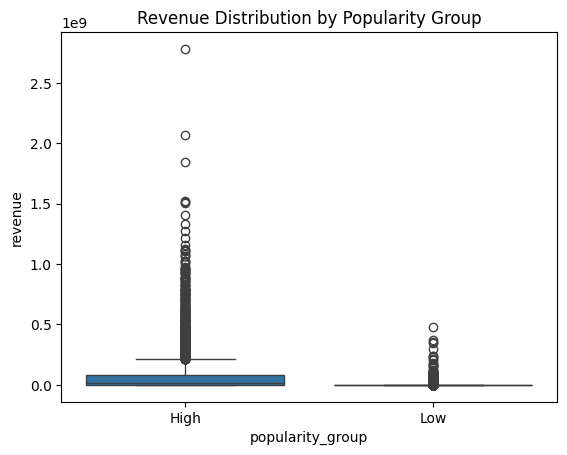

```python
import seaborn as sns
# we took the median value which is 0.385471
# to create box plots to visualize the distribution of revenues for high and low popularity groups
data['popularity_group'] = ['High' if x > 0.385471 else 'Low' for x in data['popularity']]
sns.boxplot(x='popularity_group', y='revenue', data=data)
plt.title('Revenue Distribution by Popularity Group')
plt.show()
```

```python
#Query the popularity column to seperate into high and low popularity using the median.
high_popularity = data.query('popularity > 0.385471')
low_popularity = data.query('popularity <= 0.385471')
```

```python
#Find the average of the high_popularity and low_popularity.
print('Most Popular Movies Average Revenue', high_popularity.revenue.mean())
print('Less Popular Movies Average Revenue', low_popularity.revenue.mean())
```

```
Most Popular Movies Average Revenue 76163125.2637037
Less Popular Movies Average Revenue 3968027.676111111
```

conclusions from the above investigation:

- The revenue for high popularity movies is more variable, indicating that while some high popularity movies generate a lot of revenue, others may not perform as well.
- High popularity movies generally have higher revenue, as evidenced by the higher median and the presence of more high-revenue outliers.

### What are the most common keywords associated with high-revenue movies?

In order to analyize this research question, the rawdata1 that we saved before is needed now

```python
# Step 1: defining High-Revenue Movies (separates the highest 25% of movies by revenue from the rest)
threshold = rawdata1['revenue'].quantile(0.75)
print (threshold)
```

```
33428158.5
```

```python
# Step 2: Filtering the Data
high_revenue_movies = rawdata1[rawdata1['revenue'] > threshold]
print(high_revenue_movies[['original_title', 'revenue']])
```

```
                        original_title     revenue
0                       Jurassic World  1513528810
1                   Mad Max: Fury Road   378436354
2                            Insurgent   295238201
3         Star Wars: The Force Awakens  2068178225
4                            Furious 7  1506249360
...                                ...         ...
10762                  The Deer Hunter    50000000
10764                      Up in Smoke    41590893
10770                 Midnight Express    35000000
10819                           Hooper    78000000
10822  Who's Afraid of Virginia Woolf?    33736689

[2338 rows x 2 columns]
```

```python
print(high_revenue_movies['keywords'].value_counts())
```

```
duringcreditsstinger                                                    9
mutant|marvel comic|based on comic book|superhuman|storm                3
baseball|sport|little league                                            2
exotic island|dna|paleontology|tyrannosaurus rex|velociraptor           2
elves|dwarves|orcs|middle-earth (tolkien)|hobbits                       2
                                                                       ..
con man|biography|fbi agent|overhead camera shot|attempted jailbreak    1
saving the world|secret identity|sun glasses|undercover|space marine    1
individual|resistance|radio station|war crimes|loss of family           1
self-fulfilling prophecy|evidence|hologram|dystopia                     1
alcohol|adultery|professor|married couple|son                           1
Name: keywords, Length: 2324, dtype: int64
```

```python
# Step 3: Extract and Split Keywords
# Expand the keywords into individual rows

keywords_split = high_revenue_movies['keywords'].str.split('|').explode()
```

```python
# Step 4: Count keywords and identify most common ones
keyword_counts = keywords_split.value_counts()
most_common_keywords = keyword_counts.head(10)
```

```
the most common keywords associated with high Revenue movies:
based on novel          114
duringcreditsstinger     67
dystopia                 63
new york                 55
london                   48
sport                    45
prison                   43
sequel                   42
musical                  40
sex                      37
Name: keywords, dtype: int64
```

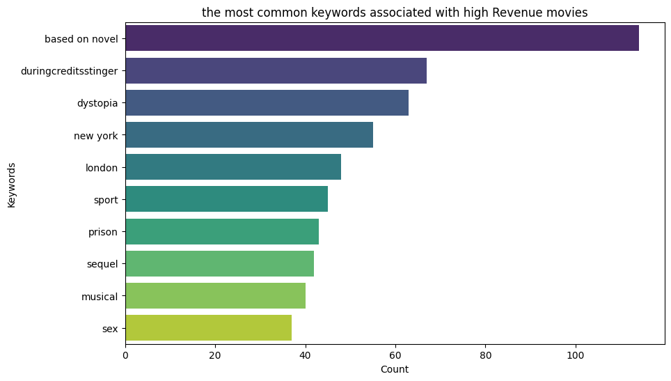

```python
# Display Data
print("the most common keywords associated with high Revenue movies: ")
print(most_common_keywords)

plt.figure(figsize=(10, 6))
sns.barplot(x=most_common_keywords.values, y=most_common_keywords.index, palette='viridis')
plt.xlabel('Count')
plt.ylabel('Keywords')
plt.title('the most common keywords associated with high Revenue movies')
plt.show()
```

- we can conclude from the graph that movies that adapt popular novels, explore complex themes like dystopia, or extend their narrative beyond the traditional ending have a higher chance of achieving significant revenue, likely due to strong fan engagement and broad appeal.

### Which directors have the highest average movie revenue?

```python
# Step 1: Group by Director
director_group = data.groupby('director')
```

```python
# Step 2: Calculate Average Revenue
average_revenue = director_group['revenue'].mean()
```

```python
# Step 3: Sort Directors by Average Revenue
sorted_directors = average_revenue.sort_values(ascending=False)
```

```python
# Step 4: Select Top Directors (e.g., top 10)
top_directors = sorted_directors.head(10)
```

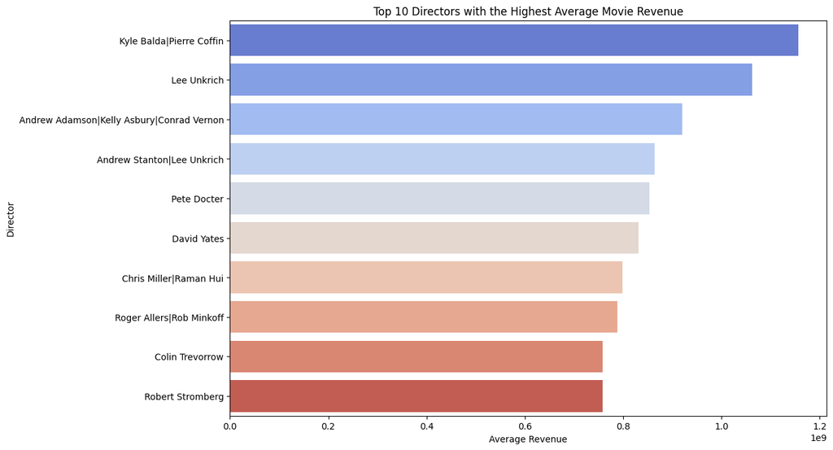

```python
# Step 5: Visualize the Results
plt.figure(figsize=(12, 8))
sns.barplot(x=top_directors.values, y=top_directors.index, palette='coolwarm')
plt.xlabel('Average Revenue')
plt.ylabel('Director')
plt.title('Top 10 Directors with the Highest Average Movie Revenue')
plt.show()
```

- Kyle Balda and Pierre Coffin lead the chart, showcasing the highest average movie revenue among the directors listed. Their success can largely be attributed to their involvement in highly successful animated franchises like "Despicable Me."
- Lee Unkrich follows closely, known for his work with Pixar, including movies like "Toy Story 3" that have enjoyed both critical acclaim and commercial success.
- Andrew Adamson, Kelly Asbury, and Conrad Vernon also appear high on the list, reflecting the strong performance of their films, particularly in the "Shrek" series.
- Directors such as David Yates, who directed the latter films of the "Harry Potter" series, and Colin Trevorrow, known for "Jurassic World," further underline the trend that directors involved in major franchises tend to generate higher average revenues.
- The presence of Roger Allers and Rob Minkoff, the directors of "The Lion King," highlights the lasting appeal and revenue-generating power of classic animated features.

```python
print(high_revenue_movies['director'].value_counts())
```

```
Steven Spielberg           25
Clint Eastwood             19
Ridley Scott               17
Ron Howard                 17
Tim Burton                 14
                           ..
Julie Taymor                1
Michael Rymer               1
Marcus Raboy                1
Robin Budd|Donovan Cook     1
Lou Adler                   1
Name: director, Length: 999, dtype: int64
```

## Is there a correlation between the revenue and the budget of movies?

Calculate the Pearson correlation coefficient

```python
correlation = data['revenue'].corr(data['budget'])
print(f'The Pearson correlation coefficient between revenue and budget is: {correlation}')
```

```
The Pearson correlation coefficient between revenue and budget is: 0.7347125084096332
```

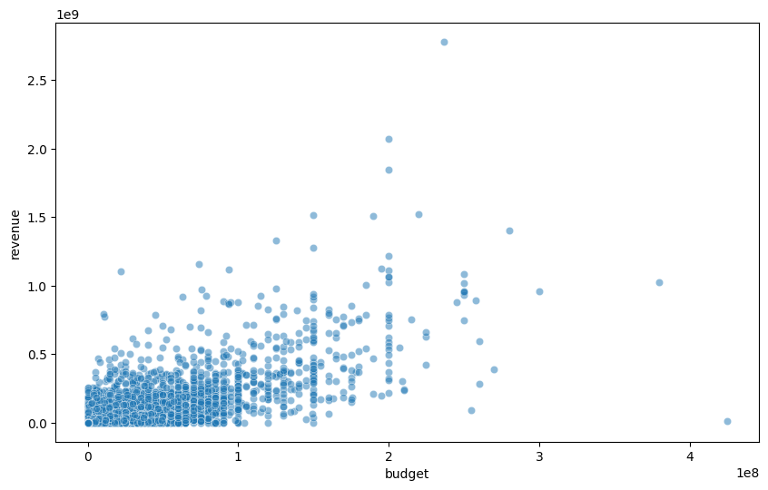

```python
# Scatter plot of revenue vs. budget
plt.figure(figsize=(10, 6))
sns.scatterplot(x='budget', y='revenue', data=data, alpha=0.5)
```

- The scatter plot demonstrates a positive correlation between movie budgets and revenues, though it's not strictly linear, films with higher budgets tend to generate higher revenues, which is expected given the likely scale of production and distribution, however, there are numerous exceptions, indicating that a high budget does not guarantee high revenue, and conversely, films can be highly profitable even with lower budgets.

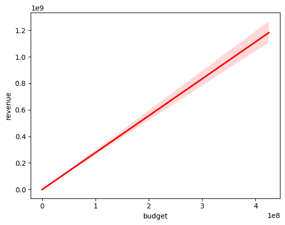

```python
# here we plot add a regression line
sns.regplot(x='budget', y='revenue', data=data, scatter=False, color='red')
```

Analysis of the Regression Line

- Positive Slope: The positive slope of the regression line indicates a positive relationship between the budget and revenue. This suggests that, on average, movies with higher budgets tend to generate higher revenues.
- Confidence Band: The shaded area around the regression line likely represents the confidence interval (often 95% confidence interval), which provides a range of values within which we can be confident that the mean response lies. The width of this band indicates the uncertainty or the variability of the revenue prediction at each budget level. A narrower band would indicate more confidence in the predictions.

### Which production companies produce the highest-grossing movies?

In order to analyize this research question, the rawdata2 that we saved before is needed now

```python
# Step 1: Split the each production company with the same row into multiple rows
production_companies_split = rawdata2['production_companies'].str.split('|').explode()
```

```python
# Step 2: Create a new DataFrame with the exploded production companies
data_exploded = rawdata2[['revenue']].join(production_companies_split.rename('production_company'))
```

```python
# Step 3: Group and Sort
# Group by production company and calculate the total revenue
company_revenue = data_exploded.groupby('production_company')['revenue'].sum()
# Sort the production companies by total revenue
sorted_company_revenue = company_revenue.sort_values(ascending=False)
```

```
production_company
Warner Bros.                              54688433698
Universal Pictures                        48134982923
Paramount Pictures                        41348789455
Twentieth Century Fox Film Corporation    37828180788
Walt Disney Pictures                      32611388637
Columbia Pictures                         29605277429
New Line Cinema                           20482023427
Amblin Entertainment                      15954216032
DreamWorks SKG                            14787064846
Touchstone Pictures                       13558288374
Name: revenue, dtype: int64
```

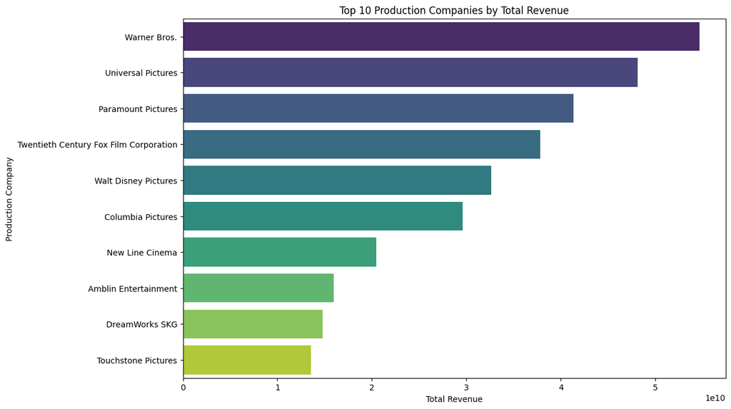

```python
# Step 4: Visulization
# Select the top 10 production companies
top_companies = sorted_company_revenue.head(10)
print(top_companies)

# Plotting the top production companies by revenue
plt.figure(figsize=(12, 8))
sns.barplot(x=top_companies.values, y=top_companies.index, palette='viridis')
plt.xlabel('Total Revenue')
plt.ylabel('Production Company')
plt.title('Top 10 Production Companies by Total Revenue')
```

### Correlation Between Vote Count/Vote Average and Revenue

```python
# STEP 1: Calculate the Pearson correlation coefficient for vote_count and revenue
correlation_vote_count_revenue = data['vote_count'].corr(data['revenue'])
print(f'The Pearson correlation coefficient between vote count and revenue is: {correlation_vote_count_revenue}')
```

```
The Pearson correlation coefficient between vote count and revenue is: 0.7910278339943613
```

```python
# STEP 2: Calculate the Pearson correlation coefficient for vote_average and revenue
correlation_vote_average_revenue = data['vote_average'].corr(data['revenue'])
print(f'The Pearson correlation coefficient between vote average and revenue is: {correlation_vote_average_revenue}')
```

```
The Pearson correlation coefficient between vote average and revenue is: 0.17502957502799546
```

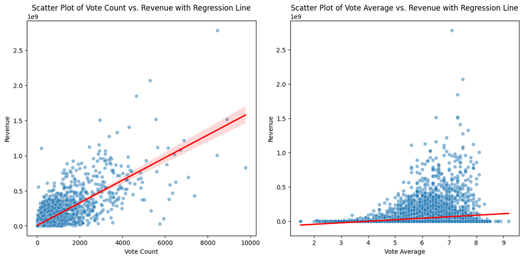

```python
# STEP 3: Visulization
plt.figure(figsize=(12, 6))
plt.subplot(1, 2, 1)
sns.scatterplot(x='vote_count', y='revenue', data=data, alpha=0.5)
sns.regplot(x='vote_count', y='revenue', data=data, scatter=False, color='red')
plt.xlabel('Vote Count')
plt.ylabel('Revenue')
plt.title('Scatter Plot of Vote Count vs. Revenue with Regression Line')

# Scatter plot of vote_average vs. revenue
plt.subplot(1, 2, 2)
sns.scatterplot(x='vote_average', y='revenue', data=data, alpha=0.5)
sns.regplot(x='vote_average', y='revenue', data=data, scatter=False, color='red')
plt.xlabel('Vote Average')
plt.ylabel('Revenue')
plt.title('Scatter Plot of Vote Average vs. Revenue with Regression Line')

plt.tight_layout()
plt.show()
```

- The data from the first plot reaffirms that engagement (as measured by vote count) can be a more reliable indicator of financial success in the film industry than critical acclaim (as measured by vote average). Movies that manage to draw more viewers to participate in voting, likely due to wide appeal or strong promotional campaigns, generally see higher revenues.
- The second plot highlights that critical acclaim, as reflected by vote averages, does not necessarily equate to box office success. This could be due to a variety of factors, including the weak appeal of highly rated films which may not attract mass audiences.

# Conclusions

### Budget and Revenue Relationship:

There is a positive correlation between a movie's budget and its revenue, suggesting that higher investments in production tend to yield higher financial returns. This trend is particularly noticeable with blockbuster movies, which often require large budgets but also generate significant box office earnings.

- Vote Count and Revenue:

The analysis shows that movies with higher vote counts generally achieve higher revenue. This implies that movies that engage more viewers—who participate in voting—are often more commercially successful.

- Vote Average and Revenue:

The relationship between vote average and revenue is weak, indicating that higher critical ratings do not necessarily correlate with financial success. This suggests that critical acclaim might not always translate into box office success.

- Genre Performance:

Genres such as Adventure and Science Fiction not only show high popularity but also bring in significant revenue, underlining their wide appeal and potential for lucrative returns. Conversely, genres like Foreign films show both lower popularity and revenue, highlighting their niche status.

### Limitations

- Causation vs. Correlation:

The conclusions drawn here are based on observed correlations and do not imply causation. Factors such as marketing effectiveness, international market reach, and competitive releases also significantly impact a movie's financial performance but were not accounted for in this analysis.

- Data Completeness:

The analysis assumes that the data is complete and representative of all movies released. However, missing data or unrecorded financials, especially for older or less mainstream films, could skew the results.

- Generalization:

While trends are noted across the dataset, individual movies may deviate significantly from these trends. The variability in film success due to creative content, directorial vision, and audience preferences is challenging to quantify and has not been captured fully in this analysis.